# R Notebook

# ———————————————————–

# Project: ISS & scRNA-seq Data Exploration

# Author: Glenn Ross-Dolan

# Date: 2025-09-19

# ———————————————————–

# Packages & setting data directory

```r
# Load libraries
library(tidyverse) # CRAN
library(Matrix) # CRAN
library(ggplot2) # CRAN
library(data.table) # CRAN
library(Seurat) # CRAN
library(dplyr) # CRAN
library(viridis) # CRAN
library(sctransform) # CRAN
library(scry) # bioconductor
library(SingleCellExperiment) # bioconductor

# Set data directory
data_dir <- "/home/glennrdx/Documents/lab_projects/microenvironments/01_data/"
```

# Load data, format, and create Seurat object

```r
# Read scRNA-seq expression data
scRNA_gene_expression <- fread(file.path(data_dir, "scRNA_gene_expression.txt")) %>% as.data.frame()
```

```
|--------------------------------------------------|
|==================================================|
```

```r
# Load cell type annotations
scRNA_cell_types <- fread(file.path(data_dir, "scRNA_cell_types.txt")) %>% as.data.frame()

  # transpose the data so genes are rows not columns (which coerses the data to a matrix). Then convert it back to a dataframe.
scRNA_gene_expression <- as.data.frame(t(scRNA_gene_expression))
  # CHECK THIS! - no barcodes in expression file so I assume they are in the same order as the meta file (and assign them to the expression matrix)
colnames(scRNA_gene_expression) <- scRNA_cell_types$Barcode

  # Clean the formatting of the annotation object
rownames(scRNA_cell_types) <- scRNA_cell_types$Barcode
scRNA_cell_types <- scRNA_cell_types[, "Annotation", drop = FALSE]

# Look at unique cell types
unique(scRNA_cell_types$Annotation)
```

```
 [1] "Stromal"                 "Macrophages_1"           "Perivascular-Like"       "Myoepi_ACTA2+"           "CD4+_T_Cells"            "DCIS 1"
 [7] "Prolif_Invasive_Tumor"   "Invasive_Tumor"          "CD8+_T_Cells"            "Endothelial"             "Macrophages_2"           "DCIS 2"
[13] "B_Cells"                 "Stromal_&_T_Cell_Hybrid" "T_Cell_&_Tumor_Hybrid"   "IRF7+_DCs"               "Mast_Cells"              "LAMP3+_DCs"
[19] "Myoepi_KRT15+"
```

```r
# Create Seurat objects
scRNA_obj = CreateSeuratObject(counts = scRNA_gene_expression, meta.data = scRNA_cell_types)
```

```r
# map boolean value to cells whether the are cancerous or not
cancerous_map <- c(
  "Stromal" = FALSE,
  "Macrophages_1" = FALSE,
  "Perivascular-Like" = FALSE,
  "Myoepi_ACTA2+" = FALSE,
  "CD4+_T_Cells" = FALSE,
  "DCIS 1" = TRUE,
  "Prolif_Invasive_Tumor" = TRUE,
  "Invasive_Tumor" = TRUE,
  "CD8+_T_Cells" = FALSE,
  "Endothelial" = FALSE,
  "Macrophages_2" = FALSE,
  "DCIS 2" = TRUE,
  "B_Cells" = FALSE,
  "Stromal_&_T_Cell_Hybrid" = FALSE,
  "T_Cell_&_Tumor_Hybrid" = TRUE,
  "IRF7+_DCs" = FALSE,
  "Mast_Cells" = FALSE,
  "LAMP3+_DCs" = FALSE,
  "Myoepi_KRT15+" = FALSE
)

# Add cancerous label to metadata
# Create a new column by matching annotations to your map
scRNA_obj$Cancerous <- unname(cancerous_map[scRNA_obj$Annotation])

# Verify
scRNA_obj@meta.data %>%
  group_by(Annotation) %>%
  summarise(
    Count = n(),
    Cancerous = unique(Cancerous)
  )
```

| Annotation | Count | Cancerous |
| --- | --- | --- |
| B_Cells | 1463 | FALSE |
| CD4+_T_Cells | 2899 | FALSE |
| CD8+_T_Cells | 1843 | FALSE |
| DCIS 1 | 1862 | TRUE |
| DCIS 2 | 2159 | TRUE |
| Endothelial | 1055 | FALSE |
| IRF7+_DCs | 210 | FALSE |
| Invasive_Tumor | 4559 | TRUE |
| LAMP3+_DCs | 103 | FALSE |
| Macrophages_1 | 2964 | FALSE |

[output cut: 9 more lines]

```r
NA
```

# QC

### Created:

- histogram of count depth
- Violin plot of MT genes
- Scatter of Both plotted against each other coloured by cell type

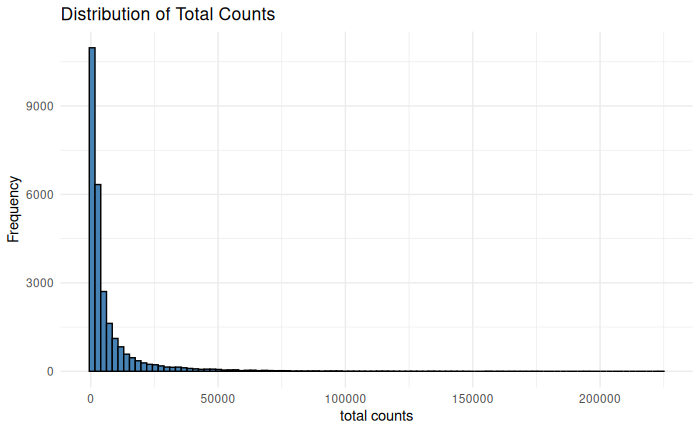

```r
# QC
# The [[ operator adds columns to object metadata. This is a great place to stash QC stats
scRNA_obj[["percent.mt"]] <- PercentageFeatureSet(scRNA_obj, pattern = "^MT-")

# 1. Histogram of nCount_RNA
ggplot(scRNA_obj@meta.data, aes(x = nCount_RNA)) +
  geom_histogram(bins = 100, fill = "steelblue", color = "black") +
  theme_minimal() +
  labs(title = "Distribution of Total Counts", x = "total counts", y = "Frequency")
```

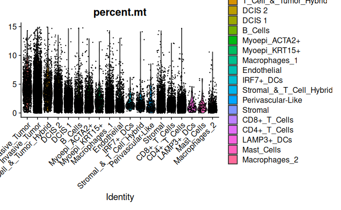

```r
# 2. Violin plot of percentage mitochondrial genes
VlnPlot(scRNA_obj, features = c('percent.mt'), pt.size = 0.01, group.by = 'Annotation', sort = 'Cancerous')
```

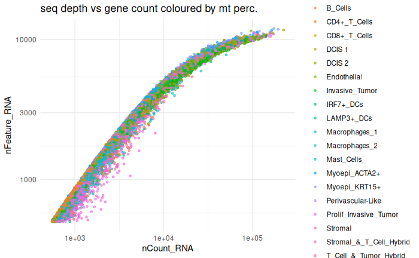

```r
# 3. Scatter plot of three metrics together
ggplot(scRNA_obj@meta.data, aes(x = nCount_RNA, y = nFeature_RNA, color = Annotation)) +
  geom_point(alpha = 0.6, size = 1) +
  theme_minimal() +
  scale_x_log10() +
  scale_y_log10() +
  labs (title = 'seq depth vs gene count coloured by mt perc.',
        x = 'nCount_RNA',
        y = 'nFeature_RNA',
        color = 'Annotation')
```

# Filtering low quality cells

## Defined is_outlier function which:

- Calculates the median value of a metric (i.e. a list of values. Could be n_counts or n_features)
- Calculates the absolute difference between each observation and the median value (absolute deviations)
- Calculate the median of these absolute deviations (MAD)
- Any values that fall n MADs from the median value of the metric is labelled an outlier

## is_outlier function is applied

Might want to remove the absolute cutoff of perc mt genes as it is redundant since we detect outlier cells by perc. mt genes and filter them out. Also might want to treat each cell type separately as each has different expression profiles for mt genes.